# MSDS 430 Milestone 1

#### Complete the following step by step instructions and submit your notebook and data file to Canvas. Your completed notebook should include all output, i.e. run each cell and save your file before submitting.

In this first milestone we will begin working toward the final project for this course. You should begin by finding a data set that contains data you find interesting. You can find some inspiration and data sets on Kaggle.com or through the university library. Keep in mind that you cannot duplicate what's been done on Kaggle (or anywhere else) for your own project, but you can choose your data set from there or at least get ideas. You will need to also import numpy, matplotlib, and pandas at the very least for this assignment. Feel free to import any other libraries you find necessary.

Step 1 (5 pts.): Explain your plans for the final project.

I will use King County (Greater Seattle) housing data: https://www.kaggle.com/harlfoxem/housesalesprediction. I'm interested in knowing about if the house price correlate to number of bedrooms, sq ft of living rooms, location/views, etc.

Step 2 (5 pts.): Read in your data file and use pandas to inspect the first 5 lines and the last 5 lines.

```python
import pandas as pd
## Read the csv file
house = pd.read_csv('kc_house_data.csv')
house.head()
```

|  | id | date | price | bedrooms | bathrooms | sqft_living | sqft_lot | floors | waterfront | view | ... | grade | sqft_above | sqft_basement | yr_built | yr_renovated | zipcode | lat | long | sqft_living15 | sqft_lot15 |
| --- | --- | --- | --- | --- | --- | --- | --- | --- | --- | --- | --- | --- | --- | --- | --- | --- | --- | --- | --- | --- | --- |
| 0 | 1999700045 | 20140502 | 313000.0 | 3 | 1.50 | 1340 | 7912 | 1.5 | 0 | 0 | ... | 7 | 1340 | 0 | 1955 | 0 | 98133 | 47.7658 | -122.339 | 1480 | 7940 |
| 1 | 1860600135 | 20140502 | 2380000.0 | 5 | 2.50 | 3650 | 9050 | 2.0 | 0 | 4 | ... | 10 | 3370 | 280 | 1921 | 0 | 98119 | 47.6345 | -122.367 | 2880 | 5400 |
| 2 | 5467900070 | 20140502 | 342000.0 | 3 | 2.00 | 1930 | 11947 | 1.0 | 0 | 0 | ... | 8 | 1930 | 0 | 1966 | 0 | 98042 | 47.3672 | -122.151 | 2200 | 12825 |
| 3 | 4040800810 | 20140502 | 420000.0 | 3 | 2.25 | 2000 | 8030 | 1.0 | 0 | 0 | ... | 8 | 1000 | 1000 | 1963 | 0 | 98008 | 47.6188 | -122.114 | 2070 | 8250 |
| 4 | 7197300105 | 20140502 | 550000.0 | 4 | 2.50 | 1940 | 10500 | 1.0 | 0 | 0 | ... | 7 | 1140 | 800 | 1976 | 0 | 98052 | 47.6830 | -122.114 | 2200 | 10500 |

5 rows × 21 columns

```python
house.tail()
```

|  | id | date | price | bedrooms | bathrooms | sqft_living | sqft_lot | floors | waterfront | view | ... | grade | sqft_above | sqft_basement | yr_built | yr_renovated | zipcode | lat | long | sqft_living15 | sqft_lot15 |
| --- | --- | --- | --- | --- | --- | --- | --- | --- | --- | --- | --- | --- | --- | --- | --- | --- | --- | --- | --- | --- | --- |
| 21608 | 5057100110 | 20150514 | 479349.0 | 5 | 3.00 | 3223 | 6371 | 2.0 | 0 | 0 | ... | 9 | 3223 | 0 | 2014 | 0 | 98042 | 47.3584 | -122.163 | 1979 | 9008 |
| 21609 | 8562790720 | 20150514 | 749950.0 | 4 | 3.50 | 2630 | 3757 | 2.0 | 0 | 0 | ... | 10 | 2200 | 430 | 2008 | 0 | 98027 | 47.5322 | -122.075 | 2620 | 2699 |
| 21610 | 7923600250 | 20150515 | 450000.0 | 5 | 2.00 | 1870 | 7344 | 1.5 | 0 | 0 | ... | 7 | 1870 | 0 | 1960 | 0 | 98007 | 47.5951 | -122.144 | 1870 | 7650 |
| 21611 | 5101400871 | 20150524 | 445500.0 | 2 | 1.75 | 1390 | 6670 | 1.0 | 0 | 0 | ... | 6 | 720 | 670 | 1941 | 0 | 98115 | 47.6914 | -122.308 | 920 | 6380 |
| 21612 | 9106000005 | 20150527 | 1310000.0 | 4 | 2.25 | 3750 | 5000 | 2.0 | 0 | 0 | ... | 8 | 2440 | 1310 | 1924 | 0 | 98115 | 47.6747 | -122.303 | 2170 | 4590 |

5 rows × 21 columns

Step 3 (5 pts.): Use numpy to perform a few calculations relevant to your goals for the final project. Explain each calculation by including comments within your code.

```python
import numpy as np

# I'll use shape attribute to know a number of rows and columns. I do not need statistics for the first two columns: id and date.
print("Shape attribute displays a number of rows and columns: ", house.shape)

# I can use numpy for rounding and getting statistics such as mean, max, min, sum, correlation, etc.
print("Mean/average values of columns [2: 21], excluding id and date columns")
print(np.round(np.mean(house.iloc[:, 2:21])))
print("Maximum values of columns [2: 21], excluding id and date columns")
print(np.round(np.max(house.iloc[:, 2:21])))
print("Minimum values of columns [2: 21], excluding id and date columns")
print(np.round(np.min(house.iloc[:, 2:21])))
```

```
Shape attribute displays a number of rows and columns:  (21613, 21)
Mean/average values of columns [2: 21], excluding id and date columns
price            540182.0
bedrooms              3.0
bathrooms             2.0
sqft_living        2080.0
sqft_lot          15107.0
floors                1.0
waterfront            0.0
view                  0.0
condition             3.0
grade                 8.0
sqft_above         1788.0
sqft_basement       292.0
yr_built           1971.0
yr_renovated         84.0
zipcode           98078.0
lat                  48.0
long               -122.0
sqft_living15      1987.0
sqft_lot15        12768.0
dtype: float64
Maximum values of columns [2: 21], excluding id and date columns
price            7700000.0
bedrooms              33.0
bathrooms              8.0
sqft_living        13540.0
sqft_lot         1651359.0
floors                 4.0
waterfront             1.0
view                   4.0
condition              5.0
grade                 13.0
sqft_above          9410.0
sqft_basement       4820.0
yr_built            2015.0
yr_renovated        2015.0
zipcode            98199.0
lat                   48.0
long                -121.0
```

[output cut: 9 more lines]

```
floors               1.0
waterfront           0.0
view                 0.0
condition            1.0
grade                1.0
sqft_above         290.0
sqft_basement        0.0
yr_built          1900.0
yr_renovated         0.0
zipcode          98001.0
lat                 47.0
long              -123.0
sqft_living15      399.0
sqft_lot15         651.0
dtype: float64
```

```python
# I can also use describe function to get all of the statistics
# using numpy round to get readable statistics of data

np.round(house.drop(['id', 'date'], axis=1).describe())
```

|  | price | bedrooms | bathrooms | sqft_living | sqft_lot | floors | waterfront | view | condition | grade | sqft_above | sqft_basement | yr_built | yr_renovated | zipcode | lat | long | sqft_living15 | sqft_lot15 |
| --- | --- | --- | --- | --- | --- | --- | --- | --- | --- | --- | --- | --- | --- | --- | --- | --- | --- | --- | --- |
| count | 21613.0 | 21613.0 | 21613.0 | 21613.0 | 21613.0 | 21613.0 | 21613.0 | 21613.0 | 21613.0 | 21613.0 | 21613.0 | 21613.0 | 21613.0 | 21613.0 | 21613.0 | 21613.0 | 21613.0 | 21613.0 | 21613.0 |
| mean | 540182.0 | 3.0 | 2.0 | 2080.0 | 15107.0 | 1.0 | 0.0 | 0.0 | 3.0 | 8.0 | 1788.0 | 292.0 | 1971.0 | 84.0 | 98078.0 | 48.0 | -122.0 | 1987.0 | 12768.0 |
| std | 367362.0 | 1.0 | 1.0 | 918.0 | 41421.0 | 1.0 | 0.0 | 1.0 | 1.0 | 1.0 | 828.0 | 443.0 | 29.0 | 402.0 | 54.0 | 0.0 | 0.0 | 685.0 | 27304.0 |
| min | 75000.0 | 0.0 | 0.0 | 290.0 | 520.0 | 1.0 | 0.0 | 0.0 | 1.0 | 1.0 | 290.0 | 0.0 | 1900.0 | 0.0 | 98001.0 | 47.0 | -123.0 | 399.0 | 651.0 |
| 25% | 321950.0 | 3.0 | 2.0 | 1427.0 | 5040.0 | 1.0 | 0.0 | 0.0 | 3.0 | 7.0 | 1190.0 | 0.0 | 1951.0 | 0.0 | 98033.0 | 47.0 | -122.0 | 1490.0 | 5100.0 |
| 50% | 450000.0 | 3.0 | 2.0 | 1910.0 | 7618.0 | 2.0 | 0.0 | 0.0 | 3.0 | 7.0 | 1560.0 | 0.0 | 1975.0 | 0.0 | 98065.0 | 48.0 | -122.0 | 1840.0 | 7620.0 |
| 75% | 645000.0 | 4.0 | 2.0 | 2550.0 | 10688.0 | 2.0 | 0.0 | 0.0 | 4.0 | 8.0 | 2210.0 | 560.0 | 1997.0 | 0.0 | 98118.0 | 48.0 | -122.0 | 2360.0 | 10083.0 |
| max | 7700000.0 | 33.0 | 8.0 | 13540.0 | 1651359.0 | 4.0 | 1.0 | 4.0 | 5.0 | 13.0 | 9410.0 | 4820.0 | 2015.0 | 2015.0 | 98199.0 | 48.0 | -121.0 | 6210.0 | 871200.0 |

```python
# check missing values in house dataset
house.isnull().sum()
# we don't have any missing/null values
```

```
id               0
date             0
price            0
bedrooms         0
bathrooms        0
sqft_living      0
sqft_lot         0
floors           0
waterfront       0
view             0
condition        0
grade            0
sqft_above       0
sqft_basement    0
yr_built         0
yr_renovated     0
zipcode          0
lat              0
long             0
sqft_living15    0
sqft_lot15       0
dtype: int64
```

Step 4 (5 pts.): Use matplotlib to create a visual display relevant to your goals for the final project. Explain your graph by including comments within your code.

```python
import matplotlib.pyplot as plt
plt.rc("font", size=14)
plt.figure(figsize=(15,8))

# I would like to see the histogram distribution for King County house price
# First let me derive histogram 10 histogram bins

## range(house.price.min(), house.price.max(), (house.price.max()-house.price.min())/10)
myBins = np.arange(house.price.min(), house.price.max(), (house.price.max()-house.price.min())/20)

ax = house.price.hist(bins = myBins, color='teal', alpha=0.8)
ax.set(xlabel='Price', ylabel='Count')
plt.show()

# King County house price is (right) skewed, let's check if mean and median are different
print("median price of house in King County", house.price.median())
print("average price of house in King County", house.price.mean())
```

[output not shown]

[output not shown]

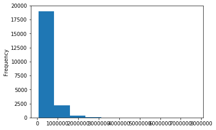

```python
# here is an easiest way of plotting house price in a histogram distribution
house.price.plot(kind='hist')
```

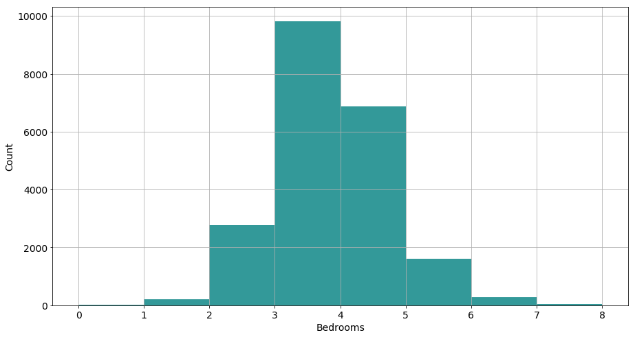

```
median number of bedrooms 3.0
average number of bedrooms 3.37084162309721
```

```python
import matplotlib.pyplot as plt
plt.rc("font", size=14)
plt.figure(figsize=(15,8))

# I would like to see the histogram distribution for house bedrooms
#ax = house.bedrooms.hist(bins=9, color='teal', alpha=0.8)
ax = house.bedrooms.hist(bins=[0, 1, 2, 3, 4, 5, 6, 7, 8], color='teal', alpha=0.8)
ax.set(xlabel='Bedrooms', ylabel='Count')
plt.show()

# bedroom numbers is (right) skewed, let's check if mean and median are different
print("median number of bedrooms", house.bedrooms.median())
print("average number of bedrooms", house.bedrooms.mean())
```

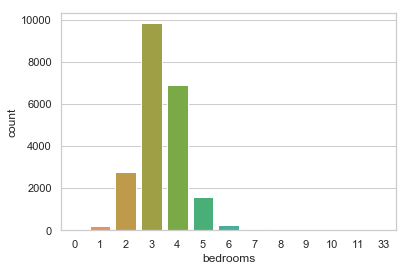

```python
# I can also use seaborn histogram without specifying bins
import seaborn as sns
sns.set(style="white") #white background style for seaborn plots
sns.set(style="whitegrid", color_codes=False)

sns.countplot(x='bedrooms',data=house)
plt.show()
```

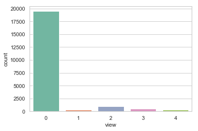

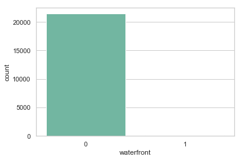

```python
sns.countplot(x='view',data=house,palette='Set2')
plt.show()
# 0 means a house has no view and 4 means a house has the best views.
# the most of houses does not have views

sns.countplot(x='waterfront',data=house,palette='Set2')
plt.show()
# there are few houses at waterfront
```

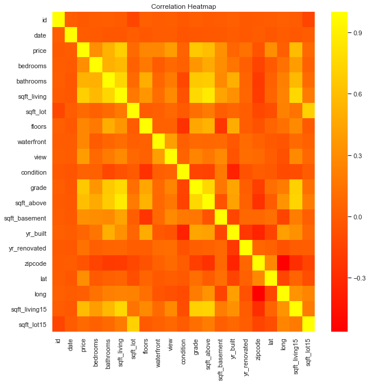

```python
## plt.matshow(house.corr())

# I would like to see a correlation heatmap of all columns
plt.subplots(figsize=(10,10))
ax = plt.axes()
ax.set_title("Correlation Heatmap")
corr = house.corr()
sns.heatmap(corr,
            xticklabels=corr.columns.values,
            yticklabels=corr.columns.values,cmap='autumn')
```

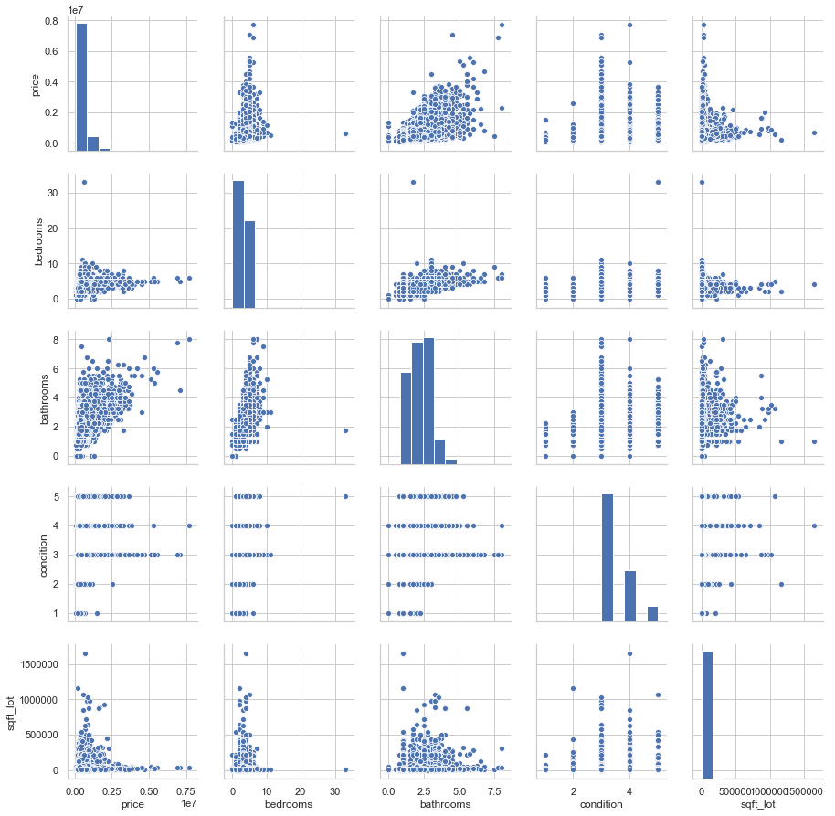

```python
## pd.plotting.scatter_matrix(house)
## sns.pairplot(house, kind="scatter")
## https://seaborn.pydata.org/generated/seaborn.pairplot.html

# I would like to see how each column intract with each other by using correlation/scatter and histogram plots
# I'm intrested to see the folloing columns:
house_zoom = house.iloc[:, house.columns.get_indexer(['price', 'bedrooms', 'bathrooms', 'condition', 'sqft_lot'])]
sns.pairplot(house_zoom , kind="scatter")
plt.show()
```

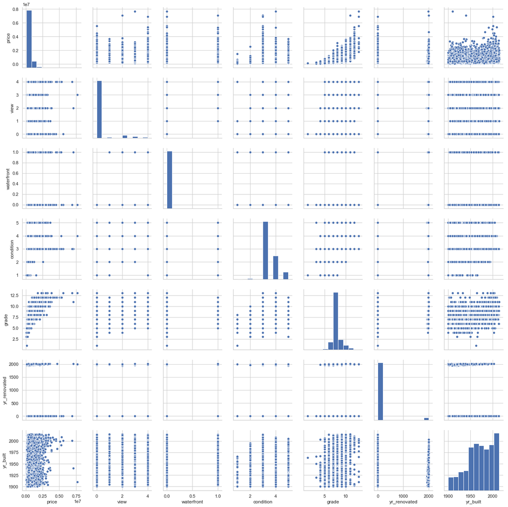

```python
# Further analysis
# Are there any corrletion between price and view?
house_view = house.iloc[:, house.columns.get_indexer(['price', 'view', 'waterfront', 'condition', 'grade', 'yr_renovated', 'yr_built'])]
sns.pairplot(house_view, kind="scatter")
plt.show()
```

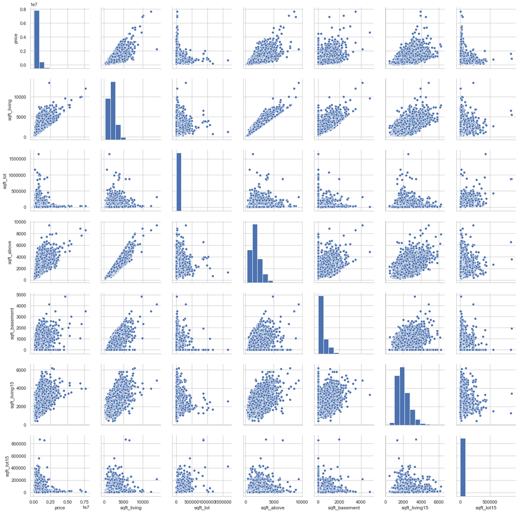

```python
# Further analysis
# Are there any corrletion between price and sqft?
house_sqft = house.iloc[:, house.columns.get_indexer(['price', 'sqft_living', 'sqft_lot', 'sqft_above', 'sqft_basement', 'sqft_living15', 'sqft_lot15'])]
sns.pairplot(house_sqft, kind="scatter")
plt.show()
```

I'll provide the interpretation/conclusion of my analyses in my final project.